# Decision Trees and Random Forests

This notebook is a revised version of the [oustanding lecture notebook](http://data100.datahub.berkeley.edu/hub/user-redirect/git-sync?repo=https://github.com/DS-100/fa19-public-archive&subPath=lecture/lec25/lec25-decision-trees.ipynb) by Professor Hug.

## Imports

As with other notebooks we will use the same set of standard imports.

```python
import numpy as np
import pandas as pd
np.random.seed(23)
```

```python
import plotly.offline as py
import plotly.express as px
import plotly.graph_objects as go
from plotly.subplots import make_subplots
import plotly.figure_factory as ff
import cufflinks as cf
cf.set_config_file(offline=True, sharing=False, theme='ggplot');
import matplotlib.pyplot as plt
import seaborn as sns
```

```python
from sklearn import datasets
from sklearn.model_selection import train_test_split
from sklearn.model_selection import cross_val_score
from sklearn.linear_model import LinearRegression
from sklearn.linear_model import LogisticRegression, LogisticRegressionCV
```

## Loading the Data

For this notebook we will use the classic [Iris Dataset](https://en.wikipedia.org/wiki/Iris_flower_data_set). The goal is to predict the species of Iris) based on measurements of the flower.

```python
iris = datasets.load_iris()
column_names = [n.replace("(cm)", "").strip() for n in iris['feature_names']]
iris_data = pd.DataFrame(iris['data'], columns=column_names)
iris_data['species'] = iris['target_names'][iris['target']]
iris_data['target'] = iris['target']
iris_data
```

|  | sepal length | sepal width | petal length | petal width | species | target |
| --- | --- | --- | --- | --- | --- | --- |
| 0 | 5.1 | 3.5 | 1.4 | 0.2 | setosa | 0 |
| 1 | 4.9 | 3.0 | 1.4 | 0.2 | setosa | 0 |
| 2 | 4.7 | 3.2 | 1.3 | 0.2 | setosa | 0 |
| 3 | 4.6 | 3.1 | 1.5 | 0.2 | setosa | 0 |
| 4 | 5.0 | 3.6 | 1.4 | 0.2 | setosa | 0 |
| ... | ... | ... | ... | ... | ... | ... |
| 145 | 6.7 | 3.0 | 5.2 | 2.3 | virginica | 2 |
| 146 | 6.3 | 2.5 | 5.0 | 1.9 | virginica | 2 |
| 147 | 6.5 | 3.0 | 5.2 | 2.0 | virginica | 2 |
| 148 | 6.2 | 3.4 | 5.4 | 2.3 | virginica | 2 |
| 149 | 5.9 | 3.0 | 5.1 | 1.8 | virginica | 2 |

150 rows × 6 columns

```python
px.scatter(iris_data, x="petal length", y="petal width", color="species")
```

[interactive chart not shown]

Notice that there are **three classes** of flower. This is a not a binary classification problem but instead a **multiclass classification problem**. There are several simple extensions of the logistic regression model to support multiple classes.

## Multiclass Logistic Regression

The logistic regression model can be extended to multiple classes using several techniques. Perhaps the simplest is the **one-versus-rest** approach where the multiclass prediction problem is divided into separate binary prediction problems.

```python
from sklearn.linear_model import LogisticRegression

lr_setosa = LogisticRegression(solver='lbfgs')
lr_setosa.fit(iris_data[['petal length', 'petal width']],
              iris_data['species'] == 'setosa')

lr_versicolor = LogisticRegression(solver='lbfgs')
lr_versicolor.fit(iris_data[['petal length', 'petal width']],
                  iris_data['species'] == 'versicolor')

lr_virginica = LogisticRegression(solver='lbfgs')
lr_virginica.fit(iris_data[['petal length', 'petal width']],
                iris_data['species'] == 'virginica');
```

```python
def predict_class(X):
    most_likely_class = np.argmax(np.vstack([
        lr_setosa.predict_proba(X)[:,1],
        lr_versicolor.predict_proba(X)[:,1],
        lr_virginica.predict_proba(X)[:,1]
    ]), axis=0)
    return iris['target_names'][most_likely_class]
```

```python
predict_class(iris_data[['petal length', 'petal width']])
```

```
array(['setosa', 'setosa', 'setosa', 'setosa', 'setosa', 'setosa',
       'setosa', 'setosa', 'setosa', 'setosa', 'setosa', 'setosa',
       'setosa', 'setosa', 'setosa', 'setosa', 'setosa', 'setosa',
       'setosa', 'setosa', 'setosa', 'setosa', 'setosa', 'setosa',
       'setosa', 'setosa', 'setosa', 'setosa', 'setosa', 'setosa',
       'setosa', 'setosa', 'setosa', 'setosa', 'setosa', 'setosa',
       'setosa', 'setosa', 'setosa', 'setosa', 'setosa', 'setosa',
       'setosa', 'setosa', 'setosa', 'setosa', 'setosa', 'setosa',
       'setosa', 'setosa', 'versicolor', 'versicolor', 'versicolor',
       'versicolor', 'versicolor', 'versicolor', 'versicolor',
       'versicolor', 'versicolor', 'versicolor', 'versicolor',
       'versicolor', 'versicolor', 'versicolor', 'versicolor',
       'versicolor', 'versicolor', 'versicolor', 'versicolor',
       'versicolor', 'virginica', 'versicolor', 'versicolor',
       'versicolor', 'versicolor', 'versicolor', 'versicolor',
       'virginica', 'versicolor', 'versicolor', 'versicolor',
       'versicolor', 'versicolor', 'virginica', 'versicolor',
       'versicolor', 'versicolor', 'versicolor', 'versicolor',
       'versicolor', 'versicolor', 'versicolor', 'versicolor',
       'versicolor', 'versicolor', 'versicolor', 'versicolor',
       'versicolor', 'setosa', 'versicolor', 'virginica', 'virginica',
       'virginica', 'virginica', 'virginica', 'virginica', 'versicolor',
       'virginica', 'virginica', 'virginica', 'virginica', 'virginica',
       'virginica', 'virginica', 'virginica', 'virginica', 'virginica',
       'virginica', 'virginica', 'virginica', 'virginica', 'virginica',
       'virginica', 'virginica', 'virginica', 'virginica', 'virginica',
       'virginica', 'virginica', 'virginica', 'virginica', 'virginica',
       'virginica', 'virginica', 'virginica', 'virginica', 'virginica',
       'virginica', 'virginica', 'virginica', 'virginica', 'virginica',
       'virginica', 'virginica', 'virginica', 'virginica', 'virginica',
       'virginica', 'virginica', 'virginica'], dtype='<U10')
```

How accurate is the model?

```python
Y = iris_data['species']
Y_hat = predict_class(iris_data[['petal length', 'petal width']])
accuracy = np.mean(Y == Y_hat)
print("Prediction Accuracy:", accuracy)
```

```
Prediction Accuracy: 0.9666666666666667
```

Scikit-learn has a built-in implementation of one versus rest.

```python
lr_model = LogisticRegression(multi_class = 'ovr', solver='lbfgs')
lr_model.fit(iris_data[["petal length", "petal width"]],
             iris_data["species"])
```

```
LogisticRegression(C=1.0, class_weight=None, dual=False, fit_intercept=True,
                   intercept_scaling=1, l1_ratio=None, max_iter=100,
                   multi_class='ovr', n_jobs=None, penalty='l2',
                   random_state=None, solver='lbfgs', tol=0.0001, verbose=0,
                   warm_start=False)
```

```python
Y_hat = lr_model.predict(iris_data[['petal length', 'petal width']])
accuracy = np.mean(Y == Y_hat)
print("Prediction Accuracy:", accuracy)
```

```
Prediction Accuracy: 0.9666666666666667
```

We can also visualize the predictions. The following code constructs a plot illustrating the decision we would make for each possible value of `petal length` and `petal width`. You don't need to understand the details of the code but the basic idea is evaluate the model on a grid (`mesgrid`) of features and color the plot the color the integer value for that feature.

```python
def plot_decision_boundaries(model, X, n=50):
    categories, z_int = np.unique(Y, return_inverse=True)
    # Make contour plot
    u = np.linspace(X[:,0].min()-0.5, X[:,0].max()+0.5, n)
    v = np.linspace(X[:,1].min()-0.5, X[:,1].max()+0.5, n)
    us,vs = np.meshgrid(u, v)
    X_test = np.c_[us.ravel(), vs.ravel()]
    z_str = model.predict(X_test)
    categories, z_int = np.unique(z_str, return_inverse=True)
    return go.Contour(x=X_test[:,0], y=X_test[:,1], z=z_int,
#                      contours=dict(start=0,end=2,size=1),
                     colorscale=px.colors.qualitative.Plotly[:3],
                     showscale=False,
                     )
```

In the following plot we can see the data points and the predicted class assignment for all combinations of peta width and petal length.

```python
fig = px.scatter(iris_data, x="petal length", y="petal width", color="species")
fig.update_traces(marker=dict(size=12, line=dict(width=2, color='black')),
                  selector=dict(mode='markers'))
fig.add_trace(
    plot_decision_boundaries(lr_model,
                             iris_data[["petal length", "petal width"]].to_numpy())
)
```

[interactive chart not shown]

## Decision Tree Classification

In lecture we introduced decision trees. In this part of the notebook, we walk through the construction of a decision tree using scikit-learn. The [scikit-learn decision tree overview](https://scikit-learn.org/stable/modules/tree.html) provides a good overview of decision trees and is worth skimming.

```python
from sklearn import tree
dt_model = tree.DecisionTreeClassifier()
dt_model.fit(iris_data[["petal length", "petal width"]],
             iris_data["species"])
```

```
DecisionTreeClassifier(class_weight=None, criterion='gini', max_depth=None,
                       max_features=None, max_leaf_nodes=None,
                       min_impurity_decrease=0.0, min_impurity_split=None,
                       min_samples_leaf=1, min_samples_split=2,
                       min_weight_fraction_leaf=0.0, presort=False,
                       random_state=None, splitter='best')
```

Notice that there are many hyperparameters that we can configure with decision trees. The parameters that you may want to pay attention to are `max_depth` and `min_samples_split` which control overfitting. `max_depth` determines how many times to divide the feature space (deeper models may overfit) and `min_samples_split` also determines the depth of the tree by preventing further splits when there are too few samples.

As with logistic regression we can make predictions using the `predict` function:

```python
dt_model.predict(iris_data[["petal length", "petal width"]])
```

```
array(['setosa', 'setosa', 'setosa', 'setosa', 'setosa', 'setosa',
       'setosa', 'setosa', 'setosa', 'setosa', 'setosa', 'setosa',
       'setosa', 'setosa', 'setosa', 'setosa', 'setosa', 'setosa',
       'setosa', 'setosa', 'setosa', 'setosa', 'setosa', 'setosa',
       'setosa', 'setosa', 'setosa', 'setosa', 'setosa', 'setosa',
       'setosa', 'setosa', 'setosa', 'setosa', 'setosa', 'setosa',
       'setosa', 'setosa', 'setosa', 'setosa', 'setosa', 'setosa',
       'setosa', 'setosa', 'setosa', 'setosa', 'setosa', 'setosa',
       'setosa', 'setosa', 'versicolor', 'versicolor', 'versicolor',
       'versicolor', 'versicolor', 'versicolor', 'versicolor',
       'versicolor', 'versicolor', 'versicolor', 'versicolor',
       'versicolor', 'versicolor', 'versicolor', 'versicolor',
       'versicolor', 'versicolor', 'versicolor', 'versicolor',
       'versicolor', 'virginica', 'versicolor', 'versicolor',
       'versicolor', 'versicolor', 'versicolor', 'versicolor',
       'versicolor', 'versicolor', 'versicolor', 'versicolor',
       'versicolor', 'versicolor', 'versicolor', 'versicolor',
       'versicolor', 'versicolor', 'versicolor', 'versicolor',
       'versicolor', 'versicolor', 'versicolor', 'versicolor',
       'versicolor', 'versicolor', 'versicolor', 'versicolor',
       'versicolor', 'versicolor', 'versicolor', 'virginica', 'virginica',
       'virginica', 'virginica', 'virginica', 'virginica', 'virginica',
       'virginica', 'virginica', 'virginica', 'virginica', 'virginica',
       'virginica', 'virginica', 'virginica', 'virginica', 'virginica',
       'virginica', 'virginica', 'virginica', 'virginica', 'virginica',
       'virginica', 'virginica', 'virginica', 'virginica', 'virginica',
       'virginica', 'virginica', 'virginica', 'virginica', 'virginica',
       'virginica', 'virginica', 'virginica', 'virginica', 'virginica',
       'virginica', 'virginica', 'virginica', 'virginica', 'virginica',
       'virginica', 'virginica', 'virginica', 'virginica', 'virginica',
       'virginica', 'virginica', 'virginica'], dtype=object)
```

One of the big advantages of decision trees is that they can be (assuming they are not too deep) interpretable while also fitting complex data. The following code creates a visualization of the tree:

```python
import graphviz
dot_data = tree.export_graphviz(dt_model, out_file=None,
                      feature_names=["petal length", "petal width"],
                      class_names=["setosa", "versicolor", "virginica"],
                      filled=True, rounded=True,
                      special_characters=True)
graph = graphviz.Source(dot_data)
#graph.render(format="png", filename="iris_tree")
graph
```

[figure not shown]

Notice at the first level that if $\textbf{petal_width} \leq 0.8$ then the iris is always a `setosa`. Then as we move further down the tree we are able to split the data into leaf nodes of just one type.

If you look carefully, you can find a leaf (leaf 7 from left to right) which has a value array that has non-zero entries in multiple classes. Why didn't the leaf get further divided? Let's examine that leaf more carefully. We can extract the tree and identify the data with high impurity:

```python
t = dt_model.tree_
leaves = t.apply(iris_data[["petal length", "petal width"]].to_numpy().astype('float32'))
impure_ind = t.impurity[leaves] > 0
iris_data.loc[impure_ind, ["petal length", "petal width", "species"]]
```

|  | petal length | petal width | species |
| --- | --- | --- | --- |
| 70 | 4.8 | 1.8 | versicolor |
| 126 | 4.8 | 1.8 | virginica |
| 138 | 4.8 | 1.8 | virginica |

Or, we can use the `predict_proba` function to return the prbabilities. Note that only the impure leaves will will have probability less than 1:

```python
impure_ind = dt_model.predict_proba(iris_data[["petal length", "petal width"]]).max(axis=1) < 1.
iris_data.loc[impure_ind, ["petal length", "petal width", "species"]]
```

|  | petal length | petal width | species |
| --- | --- | --- | --- |
| 70 | 4.8 | 1.8 | versicolor |
| 126 | 4.8 | 1.8 | virginica |
| 138 | 4.8 | 1.8 | virginica |

In either case we see that it would not be possible to divide the leaf further since all the flowers have the same features but different classes.

We can also visualize the decision surface.

```python
fig = px.scatter(iris_data, x="petal length", y="petal width", color="species")
fig.update_traces(marker=dict(size=12,
                              line=dict(width=2,
                                        color='DarkSlateGrey')),
                  selector=dict(mode='markers'))
fig.add_trace(
    plot_decision_boundaries(dt_model,
                             iris_data[["petal length", "petal width"]].to_numpy())
)
```

[interactive chart not shown]

Notice that the decision boundaries are **axis-aligned**. Why is this? Recall that we are dividing on one dimension at each node in the tree.

We can also compute the final accuracy using scikit-learn.

```python
from sklearn.metrics import accuracy_score
predictions = dt_model.predict(iris_data[["petal length", "petal width"]])
accuracy_score(predictions, iris_data["species"])
```

```
0.9933333333333333
```

## Overfitting

Let's examine overfitting with decision trees:

```python
from sklearn.model_selection import train_test_split
train_iris_data, test_iris_data = train_test_split(iris_data, test_size=0.25, random_state=42)
```

```python
#sort so that the color labels match what we had in the earlier part of lecture
train_iris_data = train_iris_data.sort_values(by="species")
test_iris_data = test_iris_data.sort_values(by="species")
```

```python
from sklearn import tree
dt_model = tree.DecisionTreeClassifier()
dt_model.fit(train_iris_data[["petal length", "petal width"]], train_iris_data["species"])
```

```
DecisionTreeClassifier(class_weight=None, criterion='gini', max_depth=None,
                       max_features=None, max_leaf_nodes=None,
                       min_impurity_decrease=0.0, min_impurity_split=None,
                       min_samples_leaf=1, min_samples_split=2,
                       min_weight_fraction_leaf=0.0, presort=False,
                       random_state=None, splitter='best')
```

```python
fig = px.scatter(train_iris_data, x="petal length", y="petal width", color="species")
fig.update_traces(marker=dict(size=12,
                              line=dict(width=2,
                                        color='DarkSlateGrey')),
                  selector=dict(mode='markers'))
fig.add_trace(
    plot_decision_boundaries(dt_model,
                             iris_data[["petal length", "petal width"]].to_numpy())
)
fig.update_layout(title="Training Data")
```

[interactive chart not shown]

```python
fig = px.scatter(test_iris_data, x="petal length", y="petal width", color="species")
fig.update_traces(marker=dict(size=12,
                              line=dict(width=2,
                                        color='DarkSlateGrey')),
                  selector=dict(mode='markers'))
fig.add_trace(
    plot_decision_boundaries(dt_model,
                             iris_data[["petal length", "petal width"]].to_numpy())
)
fig.update_layout(title="Test Data")
```

[interactive chart not shown]

```python
accuracy_score(dt_model.predict(train_iris_data[["petal length", "petal width"]]), train_iris_data["species"])
```

```
0.9910714285714286
```

```python
predictions = dt_model.predict(test_iris_data[["petal length", "petal width"]])
accuracy_score(predictions, test_iris_data["species"])
```

```
1.0
```

```python
from sklearn import tree
sepal_dt_model = tree.DecisionTreeClassifier()
sepal_dt_model.fit(train_iris_data[["sepal length", "sepal width"]], train_iris_data["species"])
```

```
DecisionTreeClassifier(class_weight=None, criterion='gini', max_depth=None,
                       max_features=None, max_leaf_nodes=None,
                       min_impurity_decrease=0.0, min_impurity_split=None,
                       min_samples_leaf=1, min_samples_split=2,
                       min_weight_fraction_leaf=0.0, presort=False,
                       random_state=None, splitter='best')
```

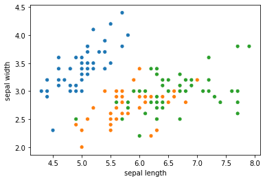

```python
sns.scatterplot(data = iris_data, x = "sepal length", y="sepal width", hue="species", legend=False)
fig = plt.gcf()
fig.savefig("iris_scatter_plot_with_petal_data_sepal_only.png", dpi=300, bbox_inches = "tight")
```

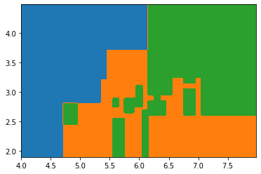

```python
from matplotlib.colors import ListedColormap
sns_cmap = ListedColormap(np.array(sns.color_palette())[0:3, :])

xx, yy = np.meshgrid(np.arange(4, 8, 0.02),
                     np.arange(1.9, 4.5, 0.02))

Z_string = sepal_dt_model.predict(np.c_[xx.ravel(), yy.ravel()])
categories, Z_int = np.unique(Z_string, return_inverse=True)
Z_int = Z_int
Z_int = Z_int.reshape(xx.shape)
cs = plt.contourf(xx, yy, Z_int, cmap=sns_cmap)
fig = plt.gcf()
fig.savefig("iris_sepal_decision_boundaries_no_data.png", dpi=300, bbox_inches = "tight")
```

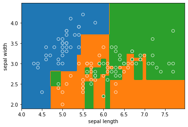

```python
from matplotlib.colors import ListedColormap
sns_cmap = ListedColormap(np.array(sns.color_palette())[0:3, :])

xx, yy = np.meshgrid(np.arange(4, 8, 0.02),
                     np.arange(1.9, 4.5, 0.02))

Z_string = sepal_dt_model.predict(np.c_[xx.ravel(), yy.ravel()])
categories, Z_int = np.unique(Z_string, return_inverse=True)
Z_int = Z_int
Z_int = Z_int.reshape(xx.shape)
cs = plt.contourf(xx, yy, Z_int, cmap=sns_cmap)
sns.scatterplot(data = train_iris_data, x = "sepal length", y="sepal width", hue="species", legend=False)
fig = plt.gcf()
fig.savefig("iris_sepal_decision_boundaries_model_training_only.png", dpi=300, bbox_inches = "tight")
```

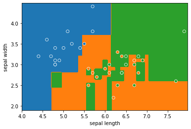

```python
from matplotlib.colors import ListedColormap
sns_cmap = ListedColormap(np.array(sns.color_palette())[0:3, :])

xx, yy = np.meshgrid(np.arange(4, 8, 0.02),
                     np.arange(1.9, 4.5, 0.02))

Z_string = sepal_dt_model.predict(np.c_[xx.ravel(), yy.ravel()])
categories, Z_int = np.unique(Z_string, return_inverse=True)
Z_int = Z_int
Z_int = Z_int.reshape(xx.shape)
cs = plt.contourf(xx, yy, Z_int, cmap=sns_cmap)
sns.scatterplot(data = test_iris_data, x = "sepal length", y="sepal width", hue="species", legend=False)
fig = plt.gcf()
fig.savefig("iris_sepal_decision_boundaries_model_test_only.png", dpi=300, bbox_inches = "tight")
#fig = plt.gcf()
#fig.savefig("iris_decision_boundaries_model_train_test_split.png", dpi=300, bbox_inches = "tight")
```

```python
dot_data = tree.export_graphviz(sepal_dt_model, out_file=None,
                      feature_names=["sepal_length", "sepal_width"],
                      class_names=["setosa", "versicolor", "virginica"],
                      filled=True, rounded=True,
                      special_characters=True)
graph = graphviz.Source(dot_data)
# graph.render(format="png", filename="sepal_tree")
graph
```

[figure not shown]

```python
accuracy_score(sepal_dt_model.predict(train_iris_data[["sepal length", "sepal width"]]),
               train_iris_data["species"])
```

```
0.9553571428571429
```

```python
accuracy_score(sepal_dt_model.predict(test_iris_data[["sepal length", "sepal width"]]),
               test_iris_data["species"])
```

```
0.6578947368421053
```

```python
dt_model_4d = tree.DecisionTreeClassifier()
all_features = ["petal length", "petal width", "sepal length", "sepal width"]
dt_model_4d.fit(train_iris_data[all_features], train_iris_data["species"])
```

```
DecisionTreeClassifier(class_weight=None, criterion='gini', max_depth=None,
                       max_features=None, max_leaf_nodes=None,
                       min_impurity_decrease=0.0, min_impurity_split=None,
                       min_samples_leaf=1, min_samples_split=2,
                       min_weight_fraction_leaf=0.0, presort=False,
                       random_state=None, splitter='best')
```

```python
predictions = dt_model_4d.predict(train_iris_data[all_features])
accuracy_score(predictions, train_iris_data["species"])
```

```
1.0
```

```python
predictions = dt_model_4d.predict(test_iris_data[all_features])
accuracy_score(predictions, test_iris_data["species"])
```

```
1.0
```

```python
dot_data = tree.export_graphviz(dt_model_4d, out_file=None,
                      feature_names=all_features,
                      class_names=["setosa", "versicolor", "virginica"],
                      filled=True, rounded=True,
                      special_characters=True)
graph = graphviz.Source(dot_data)
graph
```

[figure not shown]

```python
graph.render(format="png", filename="iris_4d_tree")
```

```
'iris_4d_tree.png'
```

### Creating Decision Trees

```python
def entropy(x):
    normalized_x = x / np.sum(x)
    return sum(-normalized_x * np.log2(normalized_x))
```

```python
-np.log2(0.33)*0.33
```

```
0.5278224832373695
```

```python
-np.log2(0.36)*0.36
```

```
0.5306152277996684
```

```python
entropy([34, 36, 40])
```

```
1.581649163979848
```

```python
entropy([149, 1, 1])
```

```
0.11485434496175385
```

```python
entropy([50, 50])
```

```
1.0
```

```python
entropy([50, 50, 50])
```

```
1.584962500721156
```

```python
entropy([31, 4, 1])
```

```
0.6815892897202809
```

```python
#entropy([50, 46, 3])
#entropy([4, 47])
#entropy([41, 50])
#entropy([50, 50])
```

```python
def weighted_average_entropy(x1, x2):
    N1 = sum(x1)
    N2 = sum(x2)
    N = N1/(N1 + N2)
    return (N1 * entropy(x1) + N2 * entropy(x2)) / (N1 + N2)
```

```python
weighted_average_entropy([50, 46, 3], [4, 47])
```

```
0.9033518322003758
```

```python
weighted_average_entropy([50, 9], [41, 50])
```

```
0.8447378399375686
```

```python
weighted_average_entropy([2, 50, 50], [48])
```

```
0.761345106024134
```

```python
weighted_average_entropy([50, 50], [50])
```

```
0.6666666666666666
```

### Random Forests

```python
ten_decision_tree_models = []
ten_training_sets = []
for i in range(10):
    current_model = tree.DecisionTreeClassifier()
    temp_iris_training_data, temp_iris_test_data = np.split(iris_data.sample(frac=1), [110])
    temp_iris_training_data = temp_iris_training_data.sort_values("species")
    current_model.fit(temp_iris_training_data[["sepal length", "sepal width"]], temp_iris_training_data["species"])
    ten_decision_tree_models.append(current_model)
    ten_training_sets.append(temp_iris_training_data)
```

```python
def plot_decision_tree(decision_tree_model, data = None, disable_axes = False):
    from matplotlib.colors import ListedColormap
    sns_cmap = ListedColormap(np.array(sns.color_palette())[0:3, :])

    xx, yy = np.meshgrid(np.arange(4, 8, 0.02),
                     np.arange(1.9, 4.5, 0.02))

    Z_string = decision_tree_model.predict(np.c_[xx.ravel(), yy.ravel()])
    categories, Z_int = np.unique(Z_string, return_inverse=True)
    Z_int = Z_int.reshape(xx.shape)
    cs = plt.contourf(xx, yy, Z_int, cmap=sns_cmap)
    if data is not None:
        sns.scatterplot(data = data, x = "sepal length", y="sepal width", hue="species", legend=False)

    if disable_axes:
        plt.axis("off")
#    if disable_axes:
#
#        plt.gca().xaxis.label.set_visible(False)
#        plt.gca().yaxis.label.set_visible(False)
```

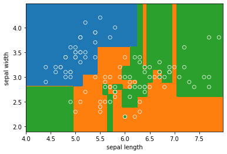

```python
m_num = 0
plot_decision_tree(ten_decision_tree_models[m_num], ten_training_sets[m_num])
plt.savefig("random_forest_model_1_example.png", dpi = 300, bbox_inches = "tight")
```

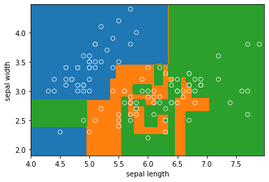

```python
m_num = 7
plot_decision_tree(ten_decision_tree_models[m_num], ten_training_sets[m_num])
plt.savefig("random_forest_model_2_example.png", dpi = 300, bbox_inches = "tight")
```

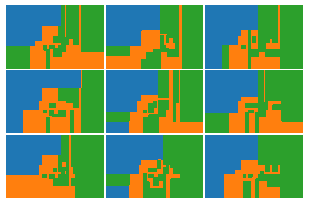

```python
import matplotlib.gridspec as gridspec
gs1 = gridspec.GridSpec(3, 3)
gs1.update(wspace=0.025, hspace=0.025) # set the spacing between axes.

for i in range(0, 9):
    plt.subplot(gs1[i]) #3, 3, i)
    plot_decision_tree(ten_decision_tree_models[i], None, True)

plt.savefig("random_forest_model_9_examples.png", dpi = 300, bbox_inches = "tight")
```